# Exercise Analysis - Barbell Lifts

SP

November 22, 2014

## Executive Summary

In this report we will analyse and quantify how well exercise enthusiasts lift barbells. The group used devices such as Jawbone Up, Nike FuelBand, and Fitbit to collect a large amount of data about their individual barbell lifts. These type of devices are part of the quantified self movement – a group of enthusiasts who take measurements about themselves regularly to improve their health, to find patterns in their behavior, or because they are tech geeks. One thing that people regularly do is quantify how much of a particular activity they do, but they rarely quantify how well they do it.

We will use data from accelerometers on the belt, forearm, arm, and dumbell of 6 participants. They were asked to perform barbell lifts correctly and incorrectly in 5 different ways. More information is available from the website here: http://groupware.les.inf.puc-rio.br/har (see the section on the Weight Lifting Exercise Dataset). The barbell lifts were classified as follows: exactly according to the specification (Class A), throwing the elbows to the front (Class B), lifting the dumbbell only halfway (Class C), lowering the dumbbell only halfway (Class D) and throwing the hips to the front (Class E). For more information read: http://groupware.les.inf.puc-rio.br/har#ixzz3J4QJLgcY

Our final objective with this analysis is to exercise the model or models we develop against a set of 20 test cases and to predict the correct class (A, B, C, D, or E) for each case.

## Load Data

We will first load the data and libraries needed for this analysis. We will make use of the multicore libraries to make best use of our hardware. *See the Appendix for system information.*

```r
# Set up parallel processing with 75% of available processors
if(Sys.info()[1] == "Windows") {
    library(doParallel)
    nCores <- round(detectCores()*0.75,0)
    registerDoParallel(cores = nCores)
} else if(Sys.info()[1] == "Darwin") {
    library(doMC)
    nCores <- round(detectCores()*0.75,0)
    registerDoMC(nCores)
}

library(caret)
library(rpart)

dataDir <- "./Data"
submitDir <- "./Submit"
trainFile <- paste0(dataDir, "/pml-training.csv")
testFile <- paste0(dataDir, "/pml-testing.csv")
trainFileURL = "https://d396qusza40orc.cloudfront.net/predmachlearn/pml-training.csv"
testFileURL = "https://d396qusza40orc.cloudfront.net/predmachlearn/pml-testing.csv"
if(!file.exists(dataDir)) dir.create(dataDir)
if(!file.exists(submitDir)) dir.create(submitDir)
if(!file.exists(trainFile)) download.file(trainFileURL, destfile = trainFile, method = "curl")
if(!file.exists(testFile)) download.file(testFileURL, destfile = trainFile, method = "curl")

# Read the csv files and make the NA values consistent.
set.seed(1912)
training <- read.csv(file = trainFile, stringsAsFactors=TRUE, na.strings = c("", "NA", "#DIV/0!"))
testing <- read.csv(file = testFile, stringsAsFactors=TRUE, na.strings = c("", "NA", "#DIV/0!"))
```

## Select Features

Next we will figure out which features will most likely give us the best results for our models. We will select features that exhibit the variances that are not zero or (near zero). Loking at the training data we see that there are a significant number of columns that mostly contain NA values. These will be eliminated from both the training data. We will also eliminate the first 7 columns as ther are irrelevant to our present analysis. We eill also eliminate columns that are sparse and columns that are highly correlated. eliminating highly correlated columns gives better results for algorithms like Random Forest. All transformations applied to the training data will also be applied to the testing data.

```r
#View(training)
cat("Remove first 7 colums:", colnames(training[,1:7]))
```

```
## Remove first 7 colums: X user_name raw_timestamp_part_1 raw_timestamp_part_2 cvtd_timestamp new_window num_window
```

```r
training <- training[, -c(1:7)]
testing<- testing[, -c(1:7)]

# Remove the NA columns
naCols <- which(sapply(training, function(x) ifelse(length(which(is.na(x))) / length(x) > .5, TRUE, FALSE)))
if(length(naCols) > 0) {
        cat("Remove columns with a large percentage of NA's: ", colnames(training[, naCols]))
        training <- training[, -naCols]
        testing <- testing[, -naCols]
} else {
        cat("There were no columns with NA's found.")
}
```

[output not shown]

```r
# compute near zero variance colums to be removed
# we will use a uniqueCut of 5%.
toEliminate <- nearZeroVar(training, freqCut = 95/64, uniqueCut = 5, saveMetrics = FALSE)
if(length(toEliminate) > 0) {
        cat("Remove the following zero or nearZero variance columns:", colnames(training[, toEliminate]))
        training <- training[, -toEliminate]
        testing <- testing[, -toEliminate]
} else {
        cat("There were no columns with zero or near zero variance found.")
}
```

```
## There were no columns with zero or near zero variance found.
```

```r
# Find any remaining sparse columns and eliminate them
sparseColumns <- checkConditionalX(training[, -c(ncol(training))], training$classe)
if(length(sparseColumns) > 0) {
        cat("Remove the following sparse columns:", colnames(training[, sparseColumns]))
        training <- training[, -sparseColumns]
        testing <- testing[, -sparseColumns]
} else {
        cat("There were no sparse columns found.")
}
```

```
## There were no sparse columns found.
```

```r
# Determine which of the remaining features are highly correlated
descrCorr <- cor(sapply(training, as.numeric))
highCorr <- findCorrelation(descrCorr, 0.90)  # threshold of 0.90
if(length(highCorr) > 0) {
        cat("Remove the following highly correlated columns:", colnames(training[, highCorr]))
        training <- training[, -highCorr]
        testing <- testing[, -highCorr]
} else {
        cat("There were no highly correlated columns found.")
}
```

```
## Remove the following highly correlated columns: accel_belt_z roll_belt accel_belt_y accel_belt_x gyros_arm_y gyros_forearm_z gyros_dumbbell_x
```

```r
# convert all data columns in training and testing data for consistency
training[,c(1:(ncol(training)-1))] <- as.data.frame(apply(training[,c(1:(ncol(training)-1))], 2, FUN = as.numeric))
testing[,c(1:(ncol(testing)-1))] <- as.data.frame(apply(testing[,c(1:(ncol(testing)-1))], 2, FUN = as.numeric))
```

## Explore Models

Next we will determine which models may be appropriate for our analysis. We will try three models including Conditional Inference Random Forest (cforest), Random Forest (rf) and Gradient Boosetd Model (gbm). First we will partition the data into a training set that will be used for training the models and into a testing set that wil be used for cross validation and out of sample error assessment.

```r
# Partition the data
set.seed(2014)
classeCol <- ncol(training)
# indentify a random working set containing about 2/5 of the total training data
workingSet <- training[createDataPartition(training[, classeCol], p = 2/5, list = FALSE), ]
# Subdivide the working set in to a training set called testDescr and a cross
# validation set called testDescr.
inTrain <- createDataPartition(workingSet[, classeCol], p = 3/4, list = FALSE)
trainDescr <- workingSet[inTrain, -classeCol]
testDescr <- workingSet[-inTrain, -classeCol]
trainClass <- workingSet[inTrain, classeCol]
testClass <- workingSet[-inTrain, classeCol]

cat("Class porportions for all training data:")
```

```
## Class porportions for all training data:
```

```r
round(prop.table(table(training$classe))*100, 2)
```

```
##
##     A     B     C     D     E
## 28.44 19.35 17.44 16.39 18.38
```

```r
#histogram( ~ training$classe, col = 'gray')
cat("Class porportions for selected sample training data:")
```

```
## Class porportions for selected sample training data:
```

```r
round(prop.table(table(trainClass))*100, 2)
```

```
## trainClass
##     A     B     C     D     E
## 28.42 19.35 17.44 16.40 18.39
```

```r
#histogram( ~ trainClass, col = 'gray')
```

The class proportions above show that the ratios of the occurance of particular classes have be maintianed through our partitioning effort. *Note: The size of the working set was directly related to the length of time it took to execute the various models. Smaller working set sizes resulted in lower accuracy and greater out-of-sample error rate for all models we considered. See the Appendix for executimes of the models for this report.*

Next we will run the 3 models using selected training and tuning parameters.

```r
#Build training parameters
False = FALSE
folds=4
repeats=5
bootControl <- trainControl(method='repeatedcv', number=folds, repeats=repeats,
                          returnResamp='all', classProbs=TRUE,
                          returnData=FALSE, savePredictions=TRUE,
                          verboseIter=TRUE, allowParallel=TRUE,
                          #summaryFunction=twoClassSummary,
                          index=createMultiFolds(trainClass[inTrain], k=folds, times=repeats))
PP <- c('center', 'scale', 'YeoJohnson')

# Run the Cforest model
set.seed(2)
crfFit <- train(trainDescr, trainClass, method = 'cforest', trControl = bootControl, metric = 'Accuracy')
crfFit
```

```
## Conditional Inference Random Forest
##
## No pre-processing
## Resampling: Cross-Validated (4 fold, repeated 5 times)
##
## Summary of sample sizes: 4419, 4785, 4786, 4786, 4784, 4419, ...
##
## Resampling results across tuning parameters:
##
##   mtry  Accuracy  Kappa  Accuracy SD  Kappa SD
##   2     0.740     0.693  0.313        0.321
##   4     0.751     0.707  0.317        0.333
##   6     0.754     0.711  0.318        0.332
##
## Accuracy was used to select the optimal model using  the largest value.
## The final value used for the model was mtry = 6.
```

```r
#crfFit$finalModel
crfElapsedTime <- crfFit$times$everything[3]/60/60

# Run the rf model
set.seed(2)
rfFit <- train(trainDescr, trainClass, method = 'rf', tunelength = 5, trControl = bootControl, metric = 'Accuracy')
rfFit
```

```
## Random Forest
##
## No pre-processing
## Resampling: Cross-Validated (4 fold, repeated 5 times)
##
## Summary of sample sizes: 4419, 4785, 4786, 4786, 4784, 4419, ...
##
## Resampling results across tuning parameters:
##
##   mtry  Accuracy  Kappa  Accuracy SD  Kappa SD
##    2    0.968     0.956  0.00548      0.00764
##   23    0.973     0.962  0.00655      0.00913
##   45    0.959     0.942  0.00987      0.01369
##
## Accuracy was used to select the optimal model using  the largest value.
## The final value used for the model was mtry = 23.
```

```r
#rfFit$finalModel
rfElapsedTime <- rfFit$times$everything[3]/60/60

# Run the gbm model
gbmGrid <- expand.grid(interaction.depth = seq(10, 16, by = 3), n.trees = (20:30) * 50, shrinkage = 0.1)
set.seed(2)
gbmFit <- train(trainDescr, trainClass, method = 'gbm', trControl = bootControl, verbose = FALSE, tuneGrid = gbmGrid)
gbmFit
```

```
## Stochastic Gradient Boosting
##
## No pre-processing
## Resampling: Cross-Validated (4 fold, repeated 5 times)
##
## Summary of sample sizes: 4419, 4785, 4786, 4786, 4784, 4419, ...
##
## Resampling results across tuning parameters:
##
##   interaction.depth  n.trees  Accuracy  Kappa  Accuracy SD  Kappa SD
##   10                 1000     0.816     0.794  0.342        0.373
##   10                 1050     0.816     0.794  0.342        0.373
##   10                 1100     0.816     0.794  0.342        0.373
##   10                 1150     0.816     0.794  0.342        0.373
##   10                 1200     0.816     0.794  0.342        0.374
##   10                 1250     0.816     0.794  0.342        0.374
##   10                 1300     0.816     0.794  0.342        0.373
##   10                 1350     0.816     0.794  0.342        0.374
##   10                 1400     0.816     0.794  0.342        0.374
##   10                 1450     0.816     0.794  0.342        0.373
##   10                 1500     0.816     0.794  0.342        0.373
##   13                 1000     0.816     0.794  0.342        0.374
##   13                 1050     0.816     0.794  0.342        0.374
##   13                 1100     0.817     0.795  0.342        0.374
##   13                 1150     0.817     0.795  0.342        0.374
##   13                 1200     0.817     0.795  0.342        0.374
##   13                 1250     0.817     0.795  0.342        0.374
##   13                 1300     0.817     0.795  0.342        0.374
##   13                 1350     0.817     0.795  0.342        0.374
##   13                 1400     0.817     0.795  0.341        0.373
##   13                 1450     0.817     0.795  0.342        0.374
##   13                 1500     0.817     0.795  0.342        0.374
##   16                 1000     0.816     0.795  0.342        0.374
##   16                 1050     0.816     0.795  0.342        0.374
##   16                 1100     0.817     0.795  0.342        0.374
##   16                 1150     0.816     0.795  0.342        0.374
##   16                 1200     0.817     0.795  0.342        0.374
##   16                 1250     0.816     0.795  0.342        0.373
##   16                 1300     0.816     0.795  0.343        0.374
##   16                 1350     0.816     0.795  0.344        0.374
##   16                 1400     0.816     0.795  0.344        0.374
##   16                 1450     0.816     0.795  0.344        0.374
##   16                 1500     0.816     0.795  0.344        0.374
##
## Tuning parameter 'shrinkage' was held constant at a value of 0.1
## Accuracy was used to select the optimal model using  the largest value.
## The final values used for the model were n.trees = 1450,
##  interaction.depth = 13 and shrinkage = 0.1.
```

```r
#gbmFit$finalModel
gbmElapsedTime <- gbmFit$times$everything[3]/60/60
```

## Model and Out-of-sample error analysis

Having created the 3 potential models we will now analyse the performance of each. We begin with plotting each of the trained models. From the plots below we can intuit that the Random Forest and Gradient Boosted models may be winners and while Conditional Inference model from shows lower accuracy it does show promise.

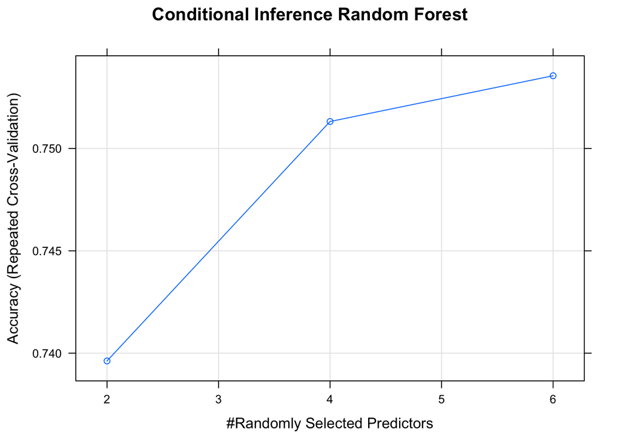

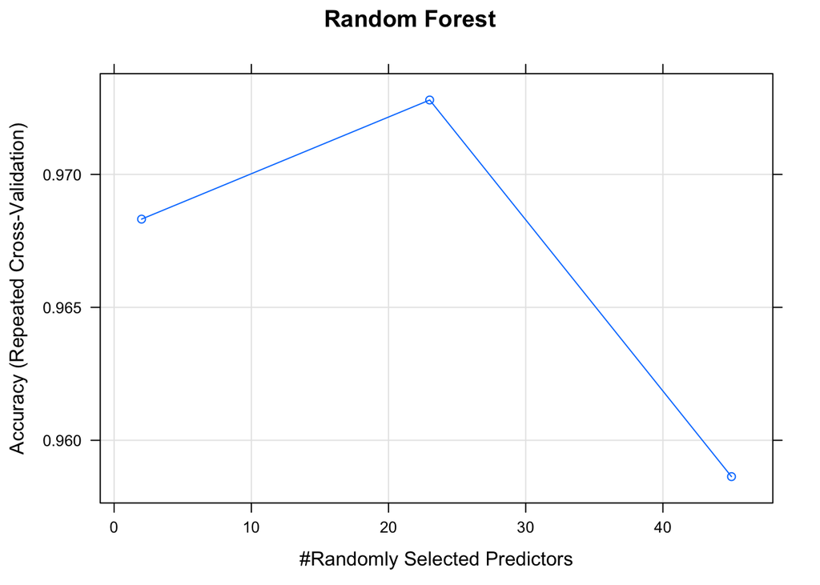

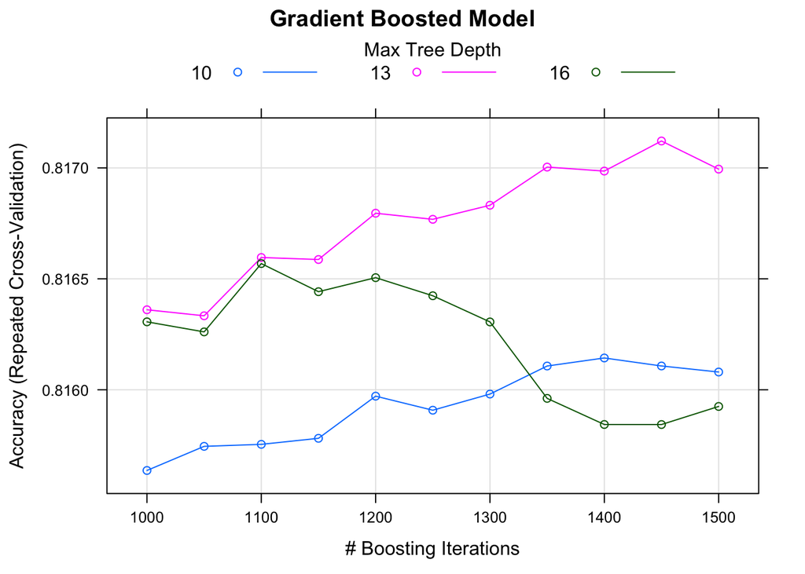

```r
p1 <- plot(crfFit, main = "Conditional Inference Random Forest")
p2 <- plot(rfFit, main = "Random Forest")
p3 <- plot(gbmFit, main = "Gradient Boosted Model")
p1; p2; p3
```

Next we will test the 3 models against the training data separated out earlier for cross validation. We will also compute the in-sample and out-of-sample error rates for comparison.

```r
crfTrainedAccuracy <- crfFit$results[crfFit$results[,1] == crfFit$bestTune[1,1], 2]
rfTrainedAccuracy <- rfFit$results[rfFit$results[,1] == rfFit$bestTune[1,1], 2]
gbmTrainedAccuracy <- gbmFit$results[gbmFit$results[,2] == gbmFit$bestTune[1,2] & gbmFit$results[,3] == gbmFit$bestTune[1,1], 4]

crfInSampleError <- 1 - crfTrainedAccuracy
rfInSampleError <- 1 - rfTrainedAccuracy
gbmInSampleError <- 1 - gbmTrainedAccuracy

crfCVResult <- predict(crfFit, newdata = testDescr)
rfCVResult <- predict(rfFit, newdata = testDescr)
gbmCVResult <- predict(gbmFit, newdata = testDescr)

crfCVAccuracy <- sum(crfCVResult == testClass) / length(testClass)
rfCVAccuracy <- sum(rfCVResult == testClass) / length(testClass)
gbmCVAccuracy <- sum(gbmCVResult == testClass) / length(testClass)

crfOutOfSampleError <- 1 - crfCVAccuracy
rfOutOfSampleError <- 1 - rfCVAccuracy
gbmOutOfSampleError <- 1 - gbmCVAccuracy
```

The in-sample error rates were as follows:  
- Conditional Inference Random Forest: 24.64%  
- Random Forest: **2.72%**  
- Gradient Boosting Model: 18.29%

The out-of-sample error rates were as follows:  
- Conditional Inference Random Forest: 7.09%  
- Random Forest: **1.68%**  
- Gradient Boosting Model: 0.97%

Comparing the in-sample and out-of-sample errors we see that the Random Forest model seems to be the most consistent performer.

## Make Predictions

Given our exploration so far and using the error rates above as a guide, we will now predict the appropriate classes for the 20 sample test dataset. We will conduct the prediction against all 3 models and compare the differences.

```r
crfPred <- predict(crfFit, newdata = testing[,-46])
rfPred <- predict(rfFit, newdata = testing[,-46])
gbmPred <- predict(gbmFit, newdata = testing[,-46])

cat("Conditional Inference Random Forests: ", as.character(crfPred))
```

```
## Conditional Inference Random Forests:  B A A A A E D D A A B C B A E E A B B B
```

```r
cat("                     Random Forests : ", as.character(rfPred))
```

```
##                      Random Forests :  B A B A A E D B A A B C B A E E A B B B
```

```r
cat("             Gradient Boosting Model: ", as.character(gbmPred))
```

```
##              Gradient Boosting Model:  B A B A A E D B A A B C B A E E A B B B
```

## Build submission set

```r
submission <- function(prefix, pred) {
        n <- length(pred)
        for (i in 1:n) {
                file <- paste0(prefix, i, ".txt")
                write.table(pred[i], file=file, quote=FALSE, row.names=FALSE,col.names=FALSE)
        }
}
submission(paste0(submitDir, "/Submitcase_"),rfPred)
```

## Appendix

```r
cat("Model Execution Times:")
```

```
## Model Execution Times:
```

```r
cat("\tcrf: ", crfElapsedTime, " hours")
```

```
##  crf:  0.4745797  hours
```

```r
cat("\t rf: ", rfElapsedTime, " hours")
```

```
##   rf:  0.06640972  hours
```

```r
cat("\tgbm: ", gbmElapsedTime, " hours")
```

```
##  gbm:  1.510701  hours
```

```r
cat("System Information")
```

```
## System Information
```

```r
Sys.info()[c(1,2,5)]
```

```
##  sysname  release  machine
## "Darwin" "14.0.0" "x86_64"
```